# EMD: Projekt z analizy danych

Zuzanna Kocur, Tomasz Supłat

06 grudnia, 2019

## Opis projektu

Celem projektu była analiza zbioru danych *sledzie.csv* i próba ustalenia wpływu poszczególnych atrybutów na długość śledzi oceanicznych wyławianych w Europie.

Na koniec stworzono model regresji liniowej w celu ustalenia, które atrybuty mają największy wpływ na długość ryby.

Następnie poprawiono wyniki za pomocą innego modelu: random forest.

## Wstępne ustawienia

Zapewniono powtarzalność wyników oraz zaimportowano niezbędne biblioteki:

```r
library(knitr)
library(rmarkdown)
library(ggplot2)
library(corrplot)
library(shiny)
library(caret)
set.seed(42)
```

## Wczytanie i wyczyszczenie danych

W pliku z danymi, brakujące informacje zastąpiono znakiem ‘?’, który przy wczytaniu zastąpiono symbolem **NA**, który reprezentuje w języku *R* brakujące wartości. Wiersze z brakującymi wartościami usunięto i pozostało około 80% wszystkich obserwacji.

```r
data <- read.csv('sledzie.csv', na.strings = '?')
len_all <- nrow(data)
data_clean <- na.omit(data)
len_not_na <- nrow(data_clean)
print(paste0("Liczba wszystkich obserwacji: ", len_all))
print(paste0("Liczba obserwacji bez brakujacyhc wartości: ", len_not_na))
knitr::kable(summary(data_clean))
```

```
## [1] "Liczba wszystkich obserwacji: 52582"
## [1] "Liczba obserwacji bez brakujacyhc wartości: 42488"
```

|  | X | length | cfin1 | cfin2 | chel1 | chel2 | lcop1 | lcop2 | fbar | recr | cumf | totaln | sst | sal | xmonth | nao |
| --- | --- | --- | --- | --- | --- | --- | --- | --- | --- | --- | --- | --- | --- | --- | --- | --- |
|  | Min. : 1 | Min. :19.0 | Min. : 0.0000 | Min. : 0.0000 | Min. : 0.000 | Min. : 5.238 | Min. : 0.3074 | Min. : 7.849 | Min. :0.0680 | Min. : 140515 | Min. :0.06833 | Min. : 144137 | Min. :12.77 | Min. :35.40 | Min. : 1.000 | Min. :-4.89000 |
|  | 1st Qu.:13233 | 1st Qu.:24.0 | 1st Qu.: 0.0000 | 1st Qu.: 0.2778 | 1st Qu.: 2.469 | 1st Qu.:13.427 | 1st Qu.: 2.5479 | 1st Qu.:17.808 | 1st Qu.:0.2270 | 1st Qu.: 360061 | 1st Qu.:0.14809 | 1st Qu.: 306068 | 1st Qu.:13.60 | 1st Qu.:35.51 | 1st Qu.: 5.000 | 1st Qu.:-1.90000 |
|  | Median :26308 | Median :25.5 | Median : 0.1111 | Median : 0.7012 | Median : 5.750 | Median :21.435 | Median : 7.0000 | Median :24.859 | Median :0.3320 | Median : 421391 | Median :0.23191 | Median : 539558 | Median :13.86 | Median :35.51 | Median : 8.000 | Median : 0.20000 |
|  | Mean :26316 | Mean :25.3 | Mean : 0.4457 | Mean : 2.0269 | Mean :10.016 | Mean :21.197 | Mean : 12.8386 | Mean :28.396 | Mean :0.3306 | Mean : 519877 | Mean :0.22987 | Mean : 515082 | Mean :13.87 | Mean :35.51 | Mean : 7.252 | Mean :-0.09642 |
|  | 3rd Qu.:39447 | 3rd Qu.:26.5 | 3rd Qu.: 0.3333 | 3rd Qu.: 1.7936 | 3rd Qu.:11.500 | 3rd Qu.:27.193 | 3rd Qu.: 21.2315 | 3rd Qu.:37.232 | 3rd Qu.:0.4650 | 3rd Qu.: 724151 | 3rd Qu.:0.29803 | 3rd Qu.: 730351 | 3rd Qu.:14.16 | 3rd Qu.:35.52 | 3rd Qu.: 9.000 | 3rd Qu.: 1.63000 |
|  | Max. :52580 | Max. :32.5 | Max. :37.6667 | Max. :19.3958 | Max. :75.000 | Max. :57.706 | Max. :115.5833 | Max. :68.736 | Max. :0.8490 | Max. :1565890 | Max. :0.39801 | Max. :1015595 | Max. :14.73 | Max. :35.61 | Max. :12.000 | Max. : 5.08000 |

## Szczegółowa analiza wartości atrybutów

Dla katego atrybutu dokonano analizy na podstawie histogramów przedstawionych poniżej. Dostępność planktonu *Calanus helgolandicus gat. 2* oraz *widłonogów gat. 2* nie przypomina konkretnego rozkładu. Wykresy dla pozostałych planktonów mają wysokie słupki w okolicach zera i długi ogon. Dla niektórych z nich, obserwacji odległych od zera było tak niewiele, że w ogóle nie widać odpowiadających im słupków.

Natężenie połowów w regionie (**fbar**) i roczny narybek (**recr**) mają zbliżone rozkłady. Łączne roczne natężenie połowów w regionie (**cumf**) i łączna liczba ryb złowionych w ramach połowu (**totaln**) mają losowe rozkłady, a temperatura przy powierzchni wody (**sst**) oraz poziom zasolenia wody (**sal**) przypominają rozkłady normalne. Rozkład normalny przyjął także atrybut **xmonth**, oznaczający miesiąc połowu, z którego można odczytać że najwięcej obserwacji w zbiorze to obserwacje z cieplejszych miesięcy (lipiec, sierpień, październik). Ostatni atrybut, oscylacja północnoatlantycka (**nao**) przypomina rozkład dwumodalny.

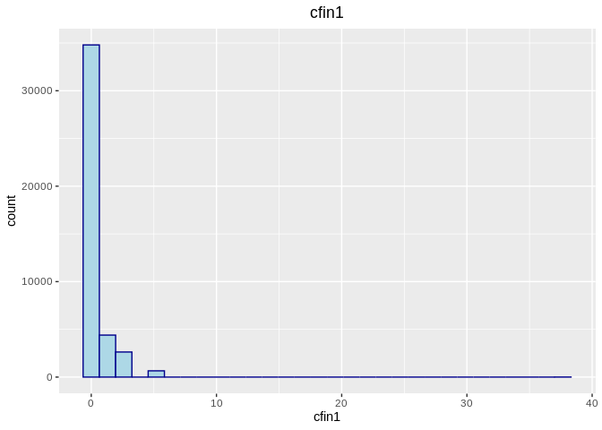

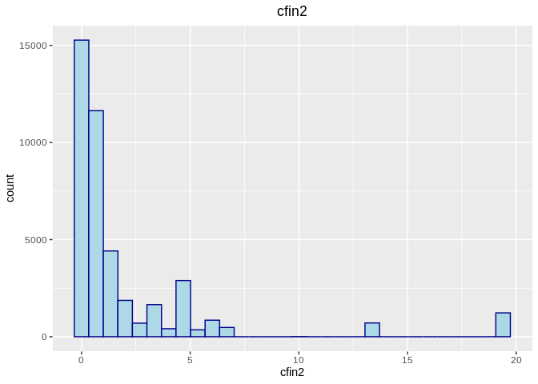

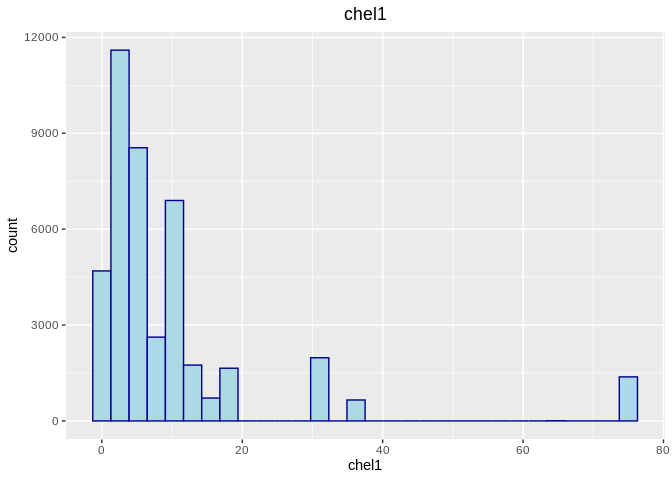

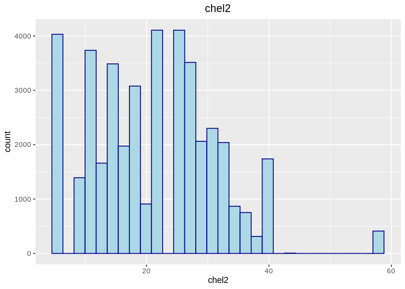

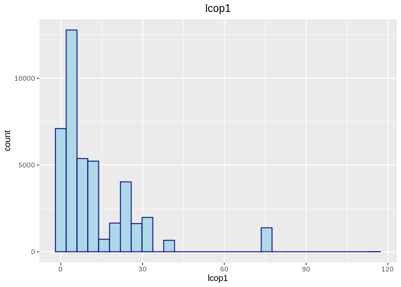

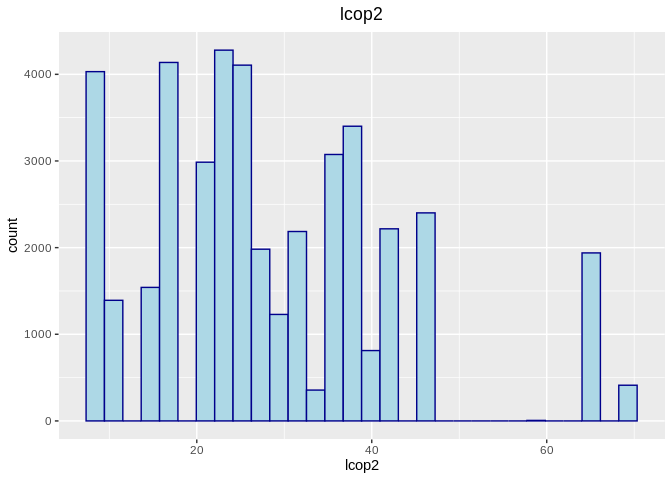

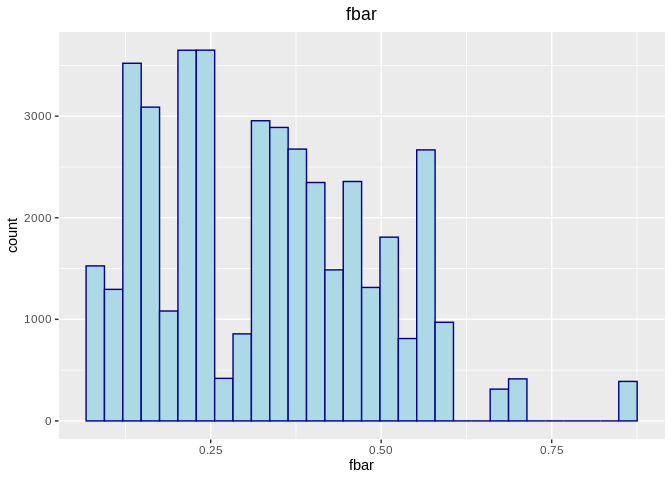

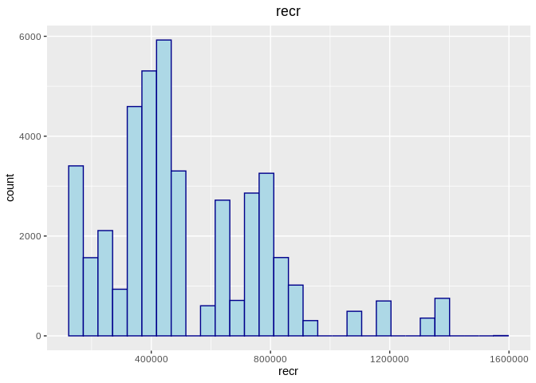

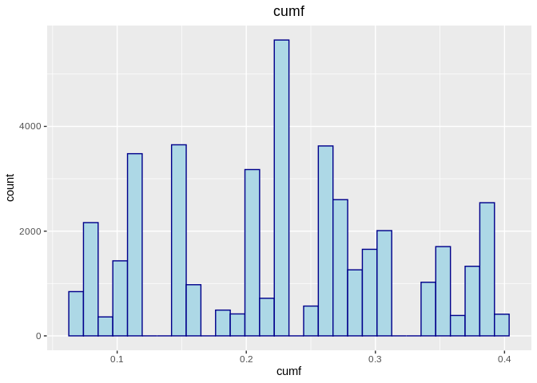

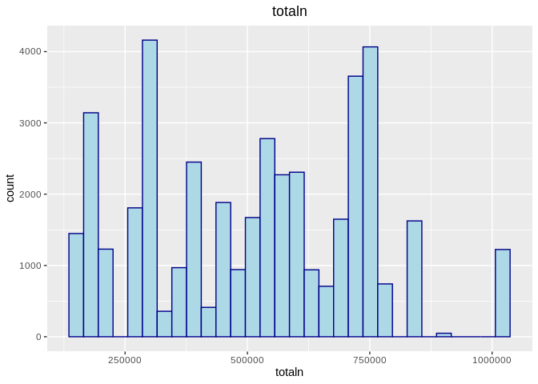

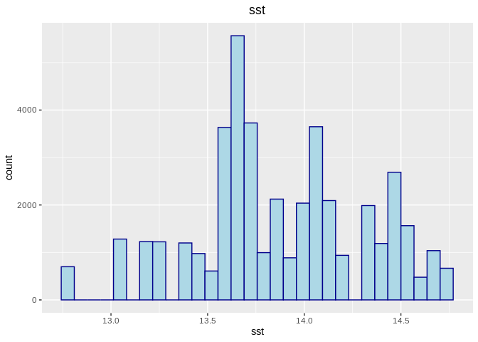

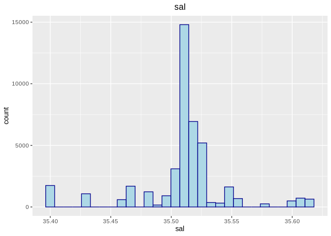

[2 more figures not shown]

## Korelacje atrybutów

Przeanalizujmy teraz czy parametry wejściowe są ze sobą skorelowane.

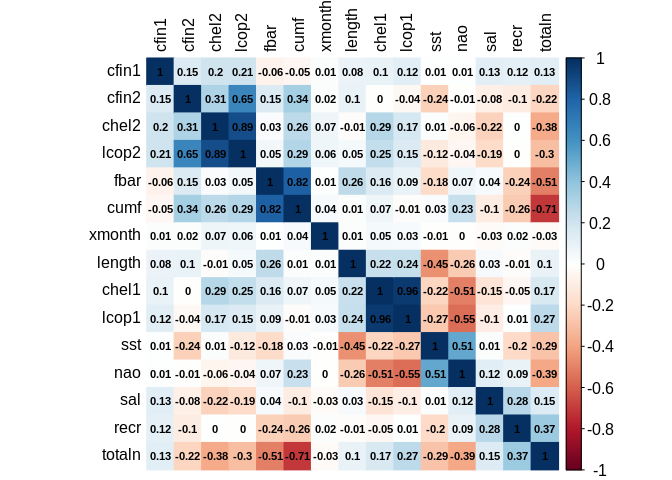

Jak widac, niektóre parametry są ze sobą silnie skorelowane:

- ‘lcop1’ oraz ‘chel1’
- ‘lcop2’ oraz ‘chel2’
- ‘lcop2’ oraz ‘cfin2’
- ‘fbar’ oraz ‘cumf’
- ‘totaln’ oraz ‘cumf’

Parametry ‘lcop’, ‘chel’ oraz ‘cfin’ odpowiadają poszczególnym gatunkom planktonu. Prawdopodobnie mają one podobne wymagania co do temperatury i innych czynników środowiskowych, przez co rozwijają się podobnie. Nie dziwi również silna korelacja pomiędzy parametrami ‘fbar’, ‘cumf’ - oba opisują natężenie połowów w regionie. Tak samo mozna wytlumaczyc silna korelację pomiedzy ‘totaln’ i ‘cumf’ - odsetek zostawionych ryb i zlowionych ryb. Poniewaz takie parametry mogą zaburzać analize danych, usuniemy część z nich: ‘lcop1’, ‘lcop2’, ‘fbar’, ‘totaln’.

Przypatrzmy się teraz parametrom które najbardziej wpływają (sa najbardziej skorelowane) na parametr ‘lenght’. Dosyć wysoka korelację ujemna ma zmienna ‘sst’ oraz zmienna ‘nao’. Natomiast dodatnio skorelowane są zmienne ‘fbar’, ‘chel1’ i ‘fcop1’.

## Regresja

Spróbujmy teraz odpowiedzieć na pytanie co jest przyczyna zmian długości śledzia. Do tego celu wytrenujemy model regresyjny. Dane wejściowe zostały podzielone na zbiór treningowy (90% danych) i testowy (10% danych). Dodatkowo do trenowania zastosujemy 5-krotna walidację.

```r
train_indices <- createDataPartition(data_clean$length, p=0.9, list = FALSE, times=1)
test_indices <- -train_indices

train_set <- data.matrix(data_clean[train_indices, -1])
test_set <- data.matrix(data_clean[test_indices, -1])

cv <- trainControl(method='cv', number=5)
```

Na początek sprawdzimy działanie najprostszego modelu, regresji liniowej. W celu polepszenia wyników, dane wejściowe zostały przeskalowane oraz wycentrowane.

```r
model <- train(length ~ cfin1+cfin2+chel1+chel2+recr+cumf+sst+sal+xmonth+nao, data = train_set, method="lm", preProcess = c('scale', 'center'), trControl=cv)
```

Następnie sprawdźmy jak nasz model radzi sobie na zbiorze testowym:

```r
predicted <- predict(model, test_set)
postResample(predicted, data_clean[test_indices, 2])
```

```
##      RMSE  Rsquared       MAE
## 1.4150780 0.2460649 1.1383371
```

```r
summary(model)
```

```
##
## Call:
## lm(formula = .outcome ~ ., data = dat)
##
## Residuals:
##     Min      1Q  Median      3Q     Max
## -6.6875 -0.9394  0.0390  0.9919  6.7518
##
## Coefficients:
##              Estimate Std. Error  t value Pr(>|t|)
## (Intercept) 25.305086   0.007333 3450.967  < 2e-16 ***
## cfin1        0.145344   0.007781   18.679  < 2e-16 ***
## cfin2       -0.036819   0.008667   -4.248 2.16e-05 ***
## chel1        0.266213   0.009185   28.983  < 2e-16 ***
## chel2       -0.076916   0.008695   -8.846  < 2e-16 ***
## recr        -0.227796   0.008639  -26.367  < 2e-16 ***
## cumf        -0.014657   0.008881   -1.650  0.09888 .
## sst         -0.810988   0.009661  -83.945  < 2e-16 ***
## sal          0.108994   0.008004   13.618  < 2e-16 ***
## xmonth       0.020065   0.007361    2.726  0.00642 **
## nao          0.129471   0.010811   11.976  < 2e-16 ***
## ---
## Signif. codes:  0 '***' 0.001 '**' 0.01 '*' 0.05 '.' 0.1 ' ' 1
##
## Residual standard error: 1.434 on 38231 degrees of freedom
## Multiple R-squared:  0.2466, Adjusted R-squared:  0.2464
## F-statistic:  1251 on 10 and 38231 DF,  p-value: < 2.2e-16
```

Nie jest to wynik imponujący, patrząc na R^2 score. Model myli się średnio o ~1.4 cm w przewidywaniach. Takie wyniki nie sa zaskoczeniem, poniewaz problem jest zlozony, a regresja liniowa jest dość prostym modelem.

Na koniec zobaczmy jakie zmienne są najważniejsze dla naszego modelu:

```r
varImp(model)
```

```
## lm variable importance
##
##        Overall
## sst    100.000
## chel1   33.213
## recr    30.034
## cfin1   20.692
## sal     14.543
## nao     12.547
## chel2    8.744
## cfin2    3.157
## xmonth   1.307
## cumf     0.000
```

Jak widzimy, najważniejsza jest temperatura wody przy powierzchni.

Zobaczmy jak zachowają się inne modele. Przetestujemy teraz random forest. Poniewaz trenowanie na pełnym zestawie danych trwa zdecydowanie za długo, do trenowania zastosujemy 10% oryginalnego zbioru (wykorzystamy do tego zbiór ‘test_set’):

```r
model_rf <- train(length ~ ., data = test_set, method="rf", ntree=100, importance= TRUE, trControl=cv)
```

Zobaczmy teraz jak nasz model radzi sobie ze zbiorem testowym (tutaj pozostałe 90% zbioru: ‘train_set’):

```r
predicted <- predict(model_rf, train_set)
postResample(predicted, data_clean[train_indices, 2])
```

```
##      RMSE  Rsquared       MAE
## 1.1750401 0.4944215 0.9260874
```

Jak widzimy, jest zdecydowanie lepiej od regresji liniowej. R^2 score jest zdecydowanie wiekszy.

Na koniec zobaczmy które zmienne mają największy wpływ na wyniki:

```r
varImp(model_rf)
```

```
## rf variable importance
##
##        Overall
## xmonth 100.000
## sst     66.785
## lcop1   28.479
## recr    22.027
## totaln  21.573
## cfin2   20.923
## chel1   19.596
## lcop2   14.722
## chel2   12.555
## fbar    12.115
## cumf     4.415
## sal      2.462
## cfin1    2.234
## nao      0.000
```

Co zaskakujace, model uznal zmienna ‘xmonth’ za najbardziej znaczaca przy przewidywaniu dlugosci sledzia. Nie jest ona praktycznie w żaden sposób skorelowana z długością śledzia. Następny jest parametr ‘sst’, czyli temperatura wody przy powierzchni.

## Wyniki

Z wykonanej analizy możemy wysunąć następujący wniosek: najprawdopodobniej temperatura wody przy powierzchni (parametr ‘sst’) jest głównym czynnikiem decydującym o długości śledzia. Jest ona dość silnie skorelowana ujemnie z długością, co sugeruje że im większa temperatura, tym śledzie są krótsze.